# xwMOOC 자연어 처리 - 텍스트

알릴레요 vs. 홍카콜라 - 댓글 분류

xwMOOC

Tidyverse Korea

2019-02-02

# 1 유튜브 댓글 분류기

[TV 홍카콜라](https://www.youtube.com/channel/UCfmicRK2-WdZMVQDrfcitLA)와 [유시민의 알릴레오](https://www.youtube.com/channel/UCJS9VvReVkplPwCIbxnbsjQ)에 달린 댓글을 바탕으로 댓글만 보고 “TV 홍카콜라” 채널에 달릴 댓글인지 “유시민의 알릴레오”에 달릴 댓글인지 예측하는 예측모형을 제작해 보자.

가장 먼저 동영상별로 댓글 자료구조를 준비한다. 그리고 나서 댓글을 예측모형 `Basetable` 데이터프레임으로 준비하는 과정을 거친고 나서 나이브 베이즈 혹은 GLM 모형을 적합시켜 예측모형을 제작해 나가는 과정을 거친다.

[figure not shown]

# 2 유튜브 트래픽

## 2.1 데이터 가져오기

[TV 홍카콜라](https://www.youtube.com/channel/UCfmicRK2-WdZMVQDrfcitLA)와 [유시민의 알릴레오](https://www.youtube.com/channel/UCJS9VvReVkplPwCIbxnbsjQ)에서 채널 고유값을 가져온다. 이를 데이터프레임으로 만들고 채널고유값을 `tuber` 팩키지 `get_all_channel_video_stats()` 함수에 넣어 유튜브 채널 트래픽 데이터를 불러와서 저장시킨다.

```r
library(tuber)
library(tidyverse)

yt_oauth(yt_app_id, yt_app_pw)

hy_channel <- list("TV홍카콜라" = "UCfmicRK2-WdZMVQDrfcitLA",
                   "알릴레오"   = "UCJS9VvReVkplPwCIbxnbsjQ")

# 1. 데이터 가져오기 -----
## 1.1 유튜브 채널 통계 -----
hy_channel_tbl <- tibble(channel = hy_channel %>% unlist, channel_name = names(hy_channel), stat =NA)

hy_video_stat_tbl <- map_df(hy_channel_tbl$channel, get_all_channel_video_stats)

hy_channel_stat_tbl <- hy_channel_tbl %>%
  mutate(stat = map(hy_channel_tbl$channel, get_all_channel_video_stats))

hy_channel_stat_tbl %>% write_rds("data/hy_channel_stat_tbl.rds")
```

## 2.2 채널 트래픽 비교

TV홍카콜라 첫방송이 “2018-12-18” “이 남자, 돌아온다.”라는 티져를 시작으로 본격적으로 방송이 되어 알릴레오와 최대한 유사한 비교 조건을 만든다. “2019-02-01” 시점기준으로 얼추 유사한 동영상 갯수임을 확인할 수 있다.

```r
library(lubridate)

hy_channel_stat_tbl <- read_rds("data/hy_channel_stat_tbl.rds")

hy_channel_stat_tbl
```

```
# A tibble: 2 x 3
  channel                  channel_name stat
  <chr>                    <chr>        <list>
1 UCfmicRK2-WdZMVQDrfcitLA TV홍카콜라   <data.frame [79 x 9]>
2 UCJS9VvReVkplPwCIbxnbsjQ 알릴레오     <data.frame [274 x 9]>
```

```r
hy_channel_stat_df <- hy_channel_stat_tbl %>%
  unnest(stat) %>%
  mutate_at(vars(contains("Count")), as.integer)

hy_channel_stat_df %>%
  mutate(date = ymd_hms(publication_date)) %>%
  filter(date >= ymd("2018-01-19")) %>%
  group_by(channel_name) %>%
  summarise(video_count         = n(),
            max_viewCount       = max(viewCount, na.rm = TRUE),
            mean_viewCount      = mean(viewCount, na.rm = TRUE),
            median_viewCount    = median(viewCount, na.rm = TRUE),
            max_likeCount       = max(likeCount, na.rm = TRUE),
            mean_likeCount      = mean(likeCount, na.rm = TRUE),
            median_likeCount    = median(likeCount, na.rm = TRUE),
            max_dislikeCount    = max(dislikeCount, na.rm = TRUE),
            mean_dislikeCount   = mean(dislikeCount, na.rm = TRUE),
            median_dislikeCount = median(dislikeCount, na.rm = TRUE),
            max_commentCount    = max(commentCount, na.rm = TRUE),
            mean_commentCount   = mean(commentCount, na.rm = TRUE),
            median_commentCount = median(commentCount, na.rm = TRUE)) %>%
  gather(metric, value, -channel_name) %>%
  spread(channel_name, value) %>%
  DT::datatable() %>%
    DT::formatRound(c(2:3), digits = 0)
```

|  | metric | TV홍카콜라 | 알릴레오 |
| --- | --- | --- | --- |
| 1 | max_commentCount | 7111 | 25505 |
| 2 | max_dislikeCount | 5088 | 26472 |
| 3 | max_likeCount | 34753 | 243251 |
| 4 | max_viewCount | 521810 | 2710734 |
| 5 | mean_commentCount | 1600.62025316456 | 1387.2 |
| 6 | mean_dislikeCount | 751.164556962025 | 745.581395348837 |
| 7 | mean_likeCount | 15125.4430379747 | 8749.67441860465 |
| 8 | mean_viewCount | 157712.493670886 | 116864.406976744 |
| 9 | median_commentCount | 1160 | 22 |
| 10 | median_dislikeCount | 413 | 10.5 |

[output cut: 3 more lines]

## 2.3 조회수 → 좋아요 전환

조회수 대비 좋아요 전환은 “TV홍카콜라”가 “알릴레오”에 비해 더 높은 것으로 나타나지만, 파괴력면에서는 “알릴레오”가 “TV홍카콜라”를 넘어서는 것으로 파악된다.

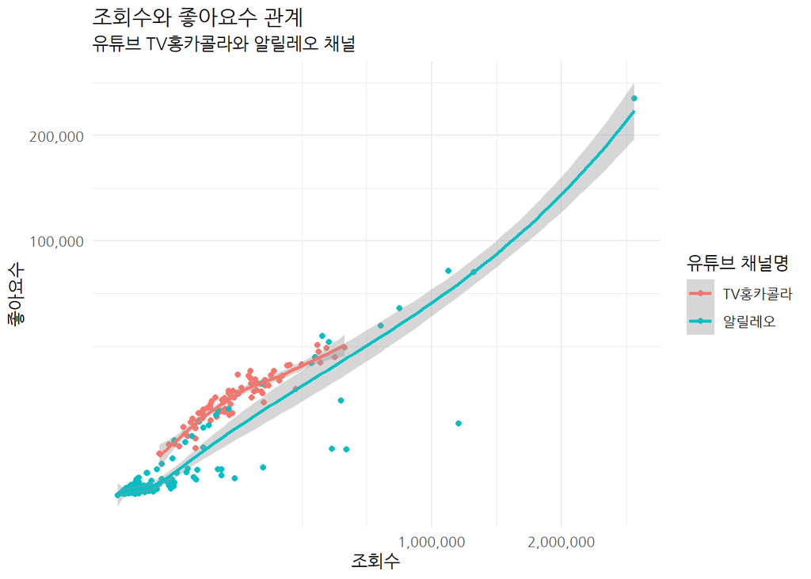

```r
library(extrafont)
loadfonts()

hy_channel_stat_df %>%
  ggplot(aes(x=viewCount, y=likeCount, color=channel_name)) +
    geom_point() +
    geom_smooth() +
    scale_x_sqrt(labels = scales::comma) +
    scale_y_sqrt(labels = scales::comma) +
    labs(x="조회수", y="좋아요수", title="조회수와 좋아요수 관계",
         subtitle="유튜브 TV홍카콜라와 알릴레오 채널", color="유튜브 채널명") +
    theme_minimal(base_family = "NanumGothic") +
    theme(legend.position = "right")
```

## 2.4 유튜브 채널별 동영상 상세

조회수 대비 좋아요 전환은 “TV홍카콜라”가 “알릴레오”에 비해 더 높은 것으로 나타나지만, 파괴력면에서는 “알릴레오”가 “TV홍카콜라”를 넘어서는 것으로 파악된다.

```r
hy_channel_stat_df %>%
  mutate(publication_date = as.Date(publication_date)) %>%
  mutate(id = paste0("<a href=https://www.youtube.com/watch?v=", id,">", id,"</a>")) %>%
  arrange(desc(viewCount)) %>%
  select(-channel, `채널`=channel_name, `동영상`=id, date=publication_date, -favoriteCount, -url) %>%
  DT::datatable(escape=FALSE, options = list(scrollX=TRUE, autoWidth = TRUE,
                                         columnDefs = list(list(width = '300px', targets = c(3))))) %>%
  DT::formatCurrency(c("viewCount", "likeCount", "dislikeCount", "commentCount"), currency = "", digits = 0)
```

|  | 채널 | 동영상 | title | date | viewCount | likeCount | dislikeCount | commentCount |
| --- | --- | --- | --- | --- | --- | --- | --- | --- |
| 1 | 알릴레오 | C03E48Ajs-M | [유시민의 알릴레오 1회] 문정인 대통령 통일외교안보 특별보좌관(1) | 2019-01-04 | 2710734 | 243251 | 26472 | 25505 |
| 2 | 알릴레오 | bV78DH5RXpY | [고칠레오 1회] 유시민, 차기 대통령 자리를 노린다? | 2019-01-07 | 1288550 | 76829 | 9207 | 7911 |
| 3 | 알릴레오 | eLJ6ftroL8g | 유시민 그리고 노무현 두 사람 이야기... | 2013-05-03 | 1179091 | 7921 | 233 | 501 |
| 4 | 알릴레오 | qU8iyOHnSzQ | [유시민의 알릴레오 2회] 문정인 대통령 통일외교안보 특별보좌관 | 2019-01-11 | 1111983 | 77872 | 4597 | 6932 |
| 5 | 알릴레오 | hQMfH-fAN_U | [유시민의 알릴레오 3회] 전지적 일자리 시점 by 문재인정부 - 정태호 청와대 일자리 수석 | 2019-01-18 | 807488 | 54076 | 2401 | 5425 |
| 6 | 알릴레오 | jkz75VIVVrc | [고칠레오 2회] "북한 핵 개발 자금 출처는 DJㆍ노무현정부" 사실일까? | 2019-01-14 | 703560 | 44175 | 3839 | 4900 |
| 7 | 알릴레오 | SwrNrFXC3VA | 14명의 구술자가 추억하는 '그때 내가 만난 노무현' | 2012-05-17 | 529854 | 3240 | 166 | 295 |
| 8 | TV홍카콜라 | NIGe-uOYK3s | [시사대담 홍크나이트 쇼] 이병태 교수 편 - 1부 '경제 폭망 이유' | 2018-12-19 | 521810 | 33759 | 2639 | 4782 |
| 9 | 알릴레오 | QhQDXvRY0BA | 2018 노무현재단 송년행사 "시민에게 듣는다" 2부 - 유시민&강원국 | 2018-12-24 | 505088 | 13787 | 1388 |  |
| 10 | TV홍카콜라 | I3U9YO8Uq2M | [TV홍카콜라] 저 홍준표가 유튜브를 시작한 이유는... | 2018-12-18 | 478174 | 29385 | 4940 | 7111 |

[output cut: 343 more lines]

## 2.5 유튜브 채널 댓글 데이터

`tuber` 팩키지 `get_all_comments()` 함수를 사용해서 댓글을 가져온다. 문제는 댓글이 없는 경우 오류가 생기기 때문에 `possibly()`를 사용해서 오류가 나더라도 후속작업을 진행시킨다.

```r
library(tictoc)

# 1. 함수형 프로그래밍 동영상 댓글 -----
get_all_comments_possibly <- possibly(get_all_comments, otherwise = NULL)

tic()
hy_video_comment_list <- map(hy_video_stat_tbl$id, get_all_comments_possibly)
toc()

# 1641.46 sec elapsed

hy_video_comment_df <- hy_video_stat_tbl %>%
  mutate(comment = hy_video_comment_list)

hy_video_comment_list %>%
  write_rds("data/hy_video_comment_list.rds")
```

## 2.6 댓글 데이터 자료형

트래픽 데이터프레임과 댓글 데이터프레임을 두 유튜브 채널별로 결합시켜 예측모형 개발에 필요한 데이터구조를 만들어낸다.

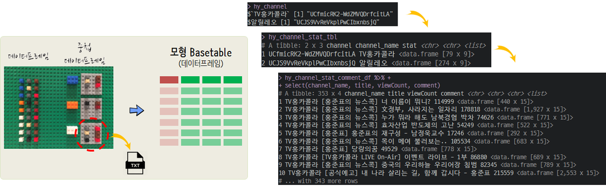

```r
hy_video_comment_list <- read_rds("data/hy_video_comment_list.rds")

hy_channel_stat_df <- hy_channel_stat_tbl %>%
  unnest(stat)

hy_channel_stat_comment_df <- hy_channel_stat_df %>%
  mutate(comment = hy_video_comment_list)

hy_channel_stat_comment_df %>%
  select(channel_name, title, viewCount, comment)
```

```
# A tibble: 353 x 4
   channel_name title                           viewCount comment
   <chr>        <chr>                           <chr>     <list>
 1 TV홍카콜라   [홍준표의 뉴스콕] 너 이름이 뭐니?~ 114999    <data.frame [440~
 2 TV홍카콜라   [홍준표의 뉴스콕] 文정부, 사라지는 일자리~ 178818    <data.frame [1,9~
 3 TV홍카콜라   [홍준표의 뉴스콕] 누가 뭐라 해도 남북경협 박차~ 74626     <data.frame [771~
 4 TV홍카콜라   [홍준표의 뉴스콕] 효자산업 반도체의 고난~ 54249     <data.frame [522~
 5 TV홍카콜라   [홍준표] 홍준표의 재구성 - 남정욱교수~ 17246     <data.frame [292~
 6 TV홍카콜라   [홍준표의 뉴스콕] 목이 메여 불러보는..~ 105534    <data.frame [683~
 7 TV홍카콜라   [홍준표] 당랑의꿈               49529     <data.frame [778~
 8 TV홍카콜라   [TV홍카콜라 LIVE On-Air] 이벤트 라이브 -~ 86880     <data.frame [689~
 9 TV홍카콜라   [홍준표의 뉴스콕] 중국의 우리하늘 우리어장 침범~ 82345     <data.frame [789~
10 TV홍카콜라   [공식예고] 내 나라 살리는 길, 함께 갑시다 - 홍준~ 215559    <data.frame [2,5~
# ... with 343 more rows
```

# 3 자연어 없는 예측모형

## 3.1 예측모형 데이터

예측모형 구축을 위해 표본 구성을 맞춘다. 즉, 클래스 불균형을 맞추고 시점도 맞추기 위해서 “2018-01-19” 이후로 TV홍카콜라와 알릴레오를 동영상 구성을 맞추고 `publication_date`에서 날짜 `feature`만 일부 추출하여 `Basetable` 모형데이터를 준비시킨다.

```r
hy_rect_basetable <- hy_channel_stat_comment_df %>%
  mutate(date = ymd_hms(publication_date)) %>%
  filter(date >= ymd("2018-01-19")) %>%
  select(channel_name, contains("Count"), date=publication_date)

hy_rect_basetable <- hy_rect_basetable %>%
  mutate(y = ifelse(channel_name == "TV홍카콜라", 0L, 1L) %>% factor(., levels=c(0, 1), labels = c("홍카콜라", "알릴레오") )) %>%
    mutate_at(vars(contains("Count")), as.integer) %>%
    mutate(date = ymd_hms(date)) %>%
    mutate(month = month(date) %>% as.factor,
           week = weekdays(date) %>%  as.factor) %>%
    select(y, contains("Count"), month, week) %>%
    mutate(month = case_when(month == 1 ~ "1월",
                             month ==12 ~ "12월",
                             TRUE ~ "기타")) %>%
    mutate(commentCount = ifelse(is.na(commentCount), 0, commentCount))

hy_rect_basetable
```

```
# A tibble: 165 x 8
   y     viewCount likeCount dislikeCount favoriteCount commentCount month
   <fct>     <int>     <int>        <int>         <int>        <dbl> <chr>
 1 홍카콜라~    114999     10659          392             1          460 12월
 2 홍카콜라~    178818     23870          528             1         2146 1월
 3 홍카콜라~     74626     11163          108             1          851 1월
 4 홍카콜라~     54249      8236           71             1          596 1월
 5 홍카콜라~     17246      2681           20             1          318 1월
 6 홍카콜라~    105534     10641          525             1          720 12월
 7 홍카콜라~     49529      5328           88             1          901 1월
 8 홍카콜라~     86880      8564          519             1          671 12월
 9 홍카콜라~     82345     11731          127             1          834 1월
10 홍카콜라~    215559     13272         2095             1         2896 12월
# ... with 155 more rows, and 1 more variable: week <fct>
```

## 3.2 예측모형 개발 [^1]

`caret` 팩키지를 사용해서 예측모형을 개발하고 성능을 파악한다.

```r
library(caret)

# 2. 예측모형 -----
## 2.1. 훈련/시험 데이터 분할 ------

y_index <- createDataPartition(hy_rect_basetable$y, times =1, p=0.7, list=FALSE)

train_df <- hy_rect_basetable[y_index, ]
test_df  <- hy_rect_basetable[-y_index, ]

## 2.2. 모형 개발/검증 데이터셋 준비 ------

cv_folds <- createMultiFolds(train_df$y, k = 10, times = 3)

cv_cntrl <- trainControl(method = "repeatedcv", number = 10,
                        repeats = 3, index = cv_folds)


## 2.2. 모형 개발/검증 데이터셋 준비 ------

library(doSNOW)
library(tictoc)
# 실행시간
tic()

cl <- makeCluster(4, type = "SOCK")
registerDoSNOW(cl)

hy_rpart <- train(y ~ ., data = train_df,
                   method = "rpart",
                   trControl = cv_cntrl,
                   preProcess = c("nzv", "center", "scale", "spatialSign"),
                   tuneLength = 7)

hy_glm   <- train(y ~ ., data = train_df,
                   method = "glm",
                   family = "binomial",
                   trControl = cv_cntrl,
                   preProcess = c("nzv", "center", "scale", "spatialSign"),
                   tuneLength = 7)

hy_rf    <- train(y ~ ., data = train_df,
                  method = "rf",
                  trControl = cv_cntrl,
                  preProcess = c("nzv", "center", "scale", "spatialSign"),
                  tuneLength = 7,
                  importance = TRUE)

stopCluster(cl)
toc()
```

```
9.12 sec elapsed
```

```r
# 4. 모형 비교평가-----
model_list <- list(
  rpart = hy_rpart,
  glm   = hy_glm,
  rf    = hy_rf
)

resamps <- resamples(model_list)
summary(resamps)
```

```
Call:
summary.resamples(object = resamps)

Models: rpart, glm, rf
Number of resamples: 30

Accuracy
           Min.   1st Qu.    Median      Mean   3rd Qu. Max. NA's
rpart 0.6363636 0.7500000 0.8333333 0.8403263 0.9090909    1    0
glm   0.6666667 0.8333333 0.9166667 0.8807692 0.9807692    1    0
rf    0.7272727 0.8333333 0.9128788 0.8974359 0.9214744    1    0

Kappa
           Min.   1st Qu.    Median      Mean   3rd Qu. Max. NA's
rpart 0.2413793 0.5000000 0.6666667 0.6806696 0.8196721    1    0
glm   0.3333333 0.6439394 0.8333333 0.7597664 0.9608434    1    0
rf    0.4406780 0.6666667 0.8216008 0.7935792 0.8408635    1    0
```

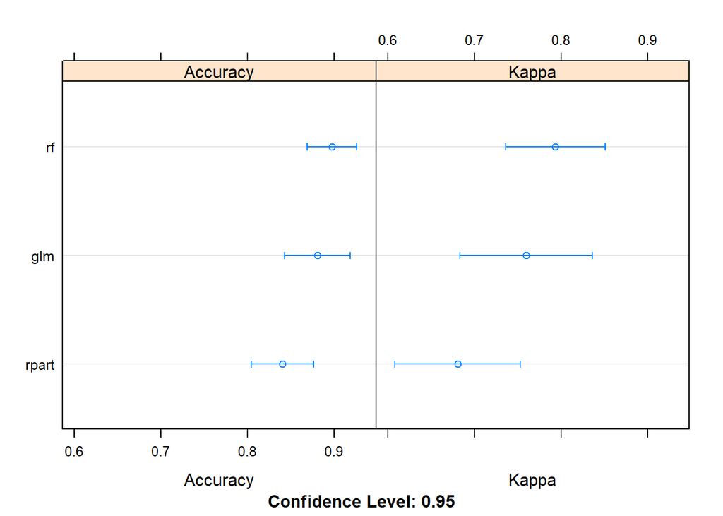

```r
dotplot(resamps)
```

```r
# 5. 모형성능 평가 -----
hy_pred_class <- predict(hy_rf, newdata = test_df)
## 혼동행렬 -----
confusionMatrix(hy_pred_class, test_df$y)
```

```
Confusion Matrix and Statistics

          Reference
Prediction 홍카콜라 알릴레오
  홍카콜라       22        2
  알릴레오        1       23

               Accuracy : 0.9375
                 95% CI : (0.828, 0.9869)
    No Information Rate : 0.5208
    P-Value [Acc > NIR] : 3.647e-10

                  Kappa : 0.875
 Mcnemar's Test P-Value : 1

            Sensitivity : 0.9565
            Specificity : 0.9200
         Pos Pred Value : 0.9167
         Neg Pred Value : 0.9583
             Prevalence : 0.4792
         Detection Rate : 0.4583
   Detection Prevalence : 0.5000
      Balanced Accuracy : 0.9383

       'Positive' Class : 홍카콜라
```